# Reproducible Research: Peer Assessment 2

Dr. B

Thursday, November 20, 2014

Impact of Severe Weather Events on Public Health and the Economy

### Synonpsis

Storms and other severe weather events can cause both public health and economic problems for communities and municipalities. Many severe events can result in fatalities, injuries, and property damage, and preventing such outcomes to the extent possible is a key concern.

This project involves exploring the U.S. National Oceanic and Atmospheric Administration’s (NOAA) storm database. This database tracks characteristics of major storms and weather events in the United States, including when and where they occur, as well as estimates of any fatalities, injuries, and property damage.

```r
# Turn off scientific notations for numbers
options(scipen = 999)

#Set locale
Sys.setlocale("LC_ALL", "English")
```

```
## [1] "LC_COLLATE=English_United States.1252;LC_CTYPE=English_United States.1252;LC_MONETARY=English_United States.1252;LC_NUMERIC=C;LC_TIME=English_United States.1252"
```

### Data Processing

The data for this assignment come in the form of a comma-separated-value file compressed via the bzip2 algorithm to reduce its size. The events in the database start in the year 1950 and end in November 2011. The dataset is downloaded and unzipped.

```r
##Set Working Directory
setwd("C:/Users/bryan_000/Documents/GitHub/Data")

##Check to see if file exists, if not download it
zip.file <- 'stormData.csv.bz2'
if (!file.exists(zip.file))
       {
                data.url <- 'http://d396qusza40orc.cloudfront.net/repdata%2Fdata%2FStormData.csv.bz2'
                download.file(data.url, zip.file)
                downloadedDataDate <- date()
       }

##Read and process the data
data <- read.csv(bzfile(zip.file),header=TRUE, stringsAsFactors = FALSE)
names(data) <- tolower(names(data))     ##make all column names lowercase
names(data) <- gsub("_","",names(data)) ##remove underscores

##Add a year column if it does not exist
if (dim(data)[2] == 37)
        {
         data$year <- as.numeric(format(as.Date(data$bgndate, format = "%m/%d/%Y %H:%M:%S"), "%Y"))
        }

##Process the property damage
data$propdmgexp <- as.character(data$propdmgexp)
data$propdmgexp[toupper(data$propdmgexp) == 'H'] <- "2"
data$propdmgexp[toupper(data$propdmgexp) == 'K'] <- "3"
data$propdmgexp[toupper(data$propdmgexp) == 'M'] <- "6"
data$propdmgexp[toupper(data$propdmgexp) == 'B'] <- "9"
data$propdmgexp <- as.numeric(data$propdmgexp)
data$propdmgexp[is.na(data$propdmgexp)] <- 0
data$totalpropdmg <- data$propdmg * 10^data$propdmgexp

##Process the crop damage
data$cropdmgexp <- as.character(data$cropdmgexp)
data$cropdmgexp[toupper(data$cropdmgexp) == 'H'] <- "2"
data$cropdmgexp[toupper(data$cropdmgexp) == 'K'] <- "3"
data$cropdmgexp[toupper(data$cropdmgexp) == 'M'] <- "6"
data$cropdmgexp[toupper(data$cropdmgexp) == 'B'] <- "9"
data$cropdmgexp <- as.numeric(data$cropdmgexp)
data$cropdmgexp[is.na(data$cropdmgexp)] <- 0
data$totalcropdmg <- data$cropdmg * 10^data$cropdmgexp

##Set the years in the print title
maintitle=paste0("For the years ",min(data$year)," to ", max(data$year))
```

There are a total of 902297 observations in this data set with 40 columns.

### Results

#### What types of events are the most harmful with respect to population health?

First, I performed an aggregate function to obtain the sum of all fatalities caused by an specific event. From that, I ordered the data in a decreasing order, took the top 10, and prepared a barplot. Next, I performed an aggregate function to obtain the sum of all injuries caused by an specific event. From that, I ordered the data in a decreasing order, took the top 10, and prepared a barplot.

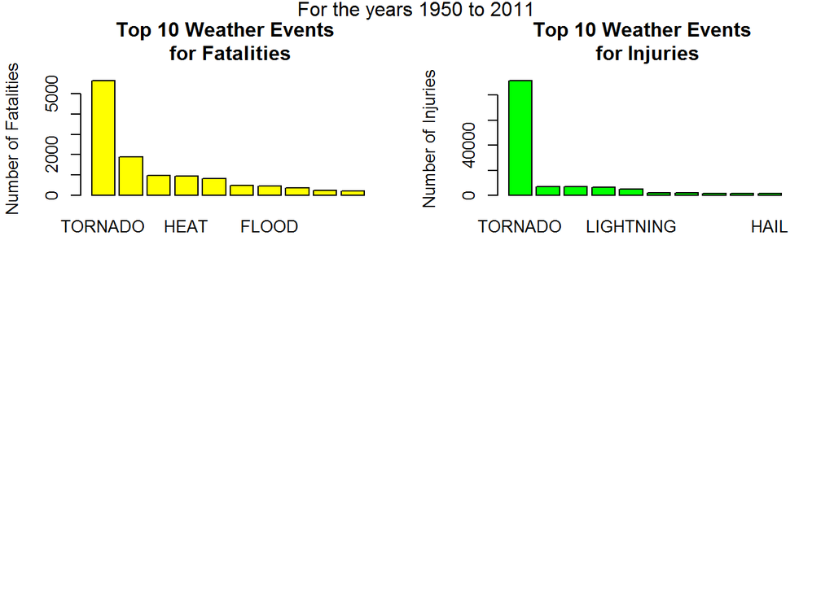

```r
##Sum the fatalities and plot the top 10
deaths <- aggregate(data$fatalities, by = list(data$evtype), "sum")
names(deaths) <- c("event", "fatalities")
deaths <- deaths[order(-deaths$fatalities), ][1:10, ]

par(mfrow=c(2,2))
barplot(deaths$fatalities, names.arg = deaths$event, col = 'yellow',main = 'Top 10 Weather Events \n for Fatalities', ylab = 'Number of Fatalities')

##Sum the injuries and plot the top 10
injuries <- aggregate(data$injuries, by = list(data$evtype), "sum")
names(injuries) <- c("event", "injuries")
injuries <- injuries[order(-injuries$injuries), ][1:10, ]

barplot(injuries$injuries, names.arg = injuries$event, col = 'green', main = 'Top 10 Weather Events \n for Injuries', ylab = 'Number of Injuries')

## Put a title over both plots
mtext(maintitle, side = 3, line = -1, outer = TRUE)
```

#### What types of events ave the greatest economic consequences?

First, I performed an aggregate function to obtain the sum of all the property damage caused by an specific event. From that, I ordered the data in a decreasing order, took the top 10, and prepared a barplot. Next, I performed an aggregate function to obtain the sum of all the crop damage caused by an specific event. From that, I ordered the data in a decreasing order, took the top 10, and prepared a barplot.

[figure not shown]

```r
##Calculate property damage and plot
sumpropdmg <- aggregate(data$totalpropdmg, by = list(data$evtype), "sum")
names(sumpropdmg) <- c("event", "cost")
sumpropdmg <- sumpropdmg[order(-sumpropdmg$cost), ][1:10, ]

par(mfrow=c(2,2))
barplot(sumpropdmg$cost, names.arg = sumpropdmg$event, col = 'blue', main = 'Top 10 Weather Events \n for Property Damage', ylab = 'Cost of Damage')

##Calculate crop damage and plot
sumcropdmg <- aggregate(data$totalcropdmg, by = list(data$evtype), "sum")
names(sumcropdmg) <- c("event", "cost")
sumcropdmg <- sumcropdmg[order(-sumcropdmg$cost), ][1:10, ]

barplot(sumcropdmg$cost, names.arg = sumpropdmg$event, col = 'red', main = 'Top 10 Weather Events \n for Crop Damage', ylab = 'Cost of Damage')

##Place a title overr both plots
mtext(maintitle, side = 3, line = -1, outer = TRUE)
```

### Conclusion

The top 10 harmful weather events to public health and the economy are as follows:

```r
summarydf <-data.frame(deathevent=deaths$event, deathnbr=deaths$fatalities, injevent=injuries$event, injnbr=injuries$injuries, propdmgevent=sumpropdmg$event,propcost=sumpropdmg$cost,cropdmgevent=sumcropdmg$event,cropcost=sumcropdmg$cost)
summarydf
```

```
##        deathevent deathnbr          injevent injnbr      propdmgevent
## 1         TORNADO     5633           TORNADO  91346             FLOOD
## 2  EXCESSIVE HEAT     1903         TSTM WIND   6957 HURRICANE/TYPHOON
## 3     FLASH FLOOD      978             FLOOD   6789           TORNADO
## 4            HEAT      937    EXCESSIVE HEAT   6525       STORM SURGE
## 5       LIGHTNING      816         LIGHTNING   5230       FLASH FLOOD
## 6       TSTM WIND      504              HEAT   2100              HAIL
## 7           FLOOD      470         ICE STORM   1975         HURRICANE
## 8     RIP CURRENT      368       FLASH FLOOD   1777    TROPICAL STORM
## 9       HIGH WIND      248 THUNDERSTORM WIND   1488      WINTER STORM
## 10      AVALANCHE      224              HAIL   1361         HIGH WIND
##        propcost      cropdmgevent    cropcost
## 1  144657709807           DROUGHT 13972566000
## 2   69305840000             FLOOD  5661968450
## 3   56947380677       RIVER FLOOD  5029459000
## 4   43323536000         ICE STORM  5022113500
## 5   16822673979              HAIL  3025954473
## 6   15735267513         HURRICANE  2741910000
## 7   11868319010 HURRICANE/TYPHOON  2607872800
## 8    7703890550       FLASH FLOOD  1421317100
## 9    6688497251      EXTREME COLD  1292973000
## 10   5270046295      FROST/FREEZE  1094086000
```